# StockResearch

Gabriel Foix

2021-03-04

Buy Quality at the a good momentum and get rid of the fishy stocks on time. That's all.

### Define candidates

Download all info needed applying the following filters:

### Factor 1: Quality

1. Healthy debts: A company shoud generate cash in order to repay its debt. The **Free Cash Flow to Debt** ratio is a good indicator of how quick a company pays back its debt. The lower this ratio the better.

FCF2D = $\frac{Debt}{Free Cash Flow}$

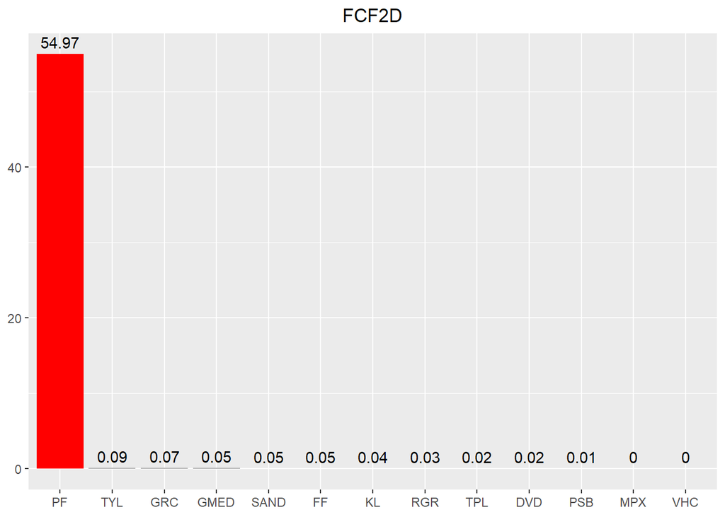

2. Profitability: ROA

[figure not shown]

3. High Margin: We look for companies that generate free cash flow compare to its price. The **Free Cash Flow to Entreprise Value** ratio tells us how many years of cash flow would be needed to the return the 100% of the investment. Again, the lower, the better. Values bellow 1 would mean "free lunch".

FCF2EV = $\frac{EV}{Free Cash Flow}$

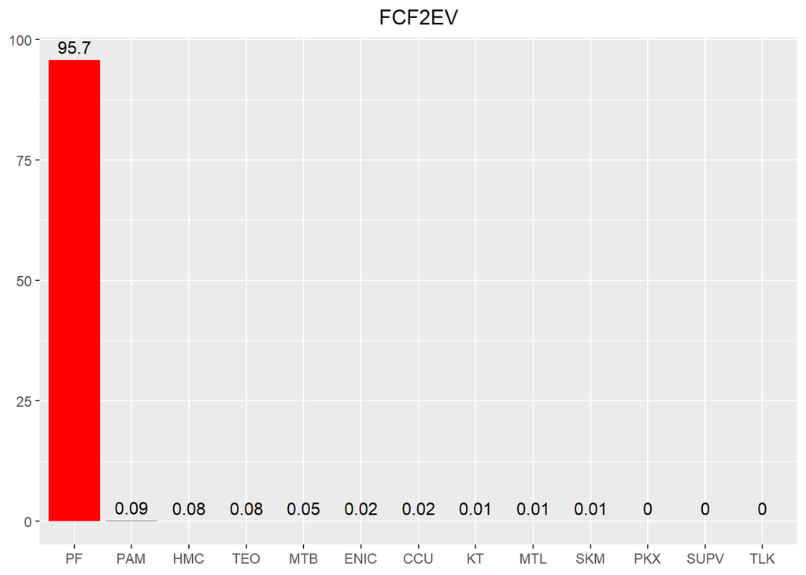

#### Download Historical Data

Download only stocks not filtered previously

### Value touch

Filter out stocks with PER > 40

Report Candidates

Filter Summary

| Filter | NStocks |
| --- | --- |
| Initial | 3221 |
| ROA | 1517 |
| FCF | 1517 |
| Hist1Y | 1517 |
| PER | 1517 |

### Factor 2: Momentum

Don't hold onto a stock simply because it is high quality. So called quality stocks have cycles too. Stan Weinstein (page 177)

Generic Intermediate-Term Momentum Based on Gray-Vogel (page 80)

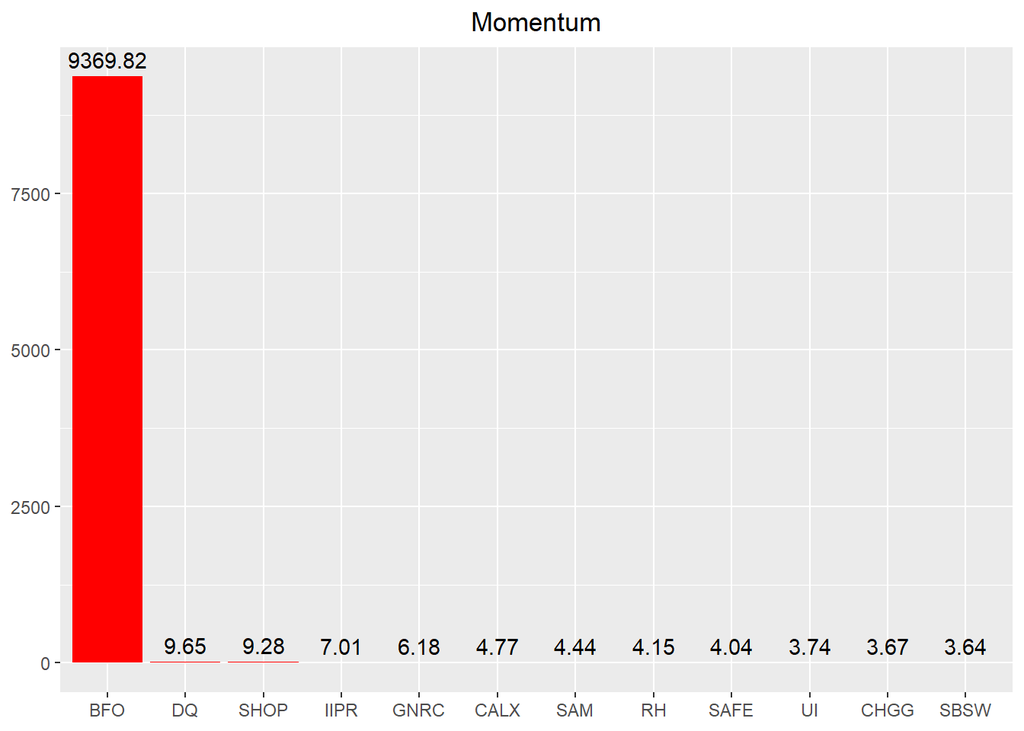

### Factor 3: Timing Signal

Sell Signal - Pr < 1% SMA 30 weeks and slope negative (< -0.2)  
Buy Signal - 109% * SMA30 < Pr > SMA 30 and slope positive (> 0.2)  
Hold Signal - Neither Buy nor Sell

#### Calc Market Cap

Using free float shares

### Summary

Summary

| Ticker | Signal | Quality | Momentum | Final_rank | PER | MCap |
| --- | --- | --- | --- | --- | --- | --- |
| AAN | NA | 1443.0 | 1501 | 1513.0 | 0.0000000 | 0 |
| SID | HOLD | 1454.0 | 1427 | 1510.0 | 8.5893856 | 3950771857 |
| MOH | HOLD | 1426.0 | 1443 | 1509.0 | 18.7088162 | 11451727741 |
| YETI | BUY | 1387.5 | 1480 | 1508.0 | 36.7740092 | 5330375235 |
| VHC | HOLD | 1485.0 | 1378 | 1505.5 | 1.5502129 | 388820861 |
| DECK | HOLD | 1381.0 | 1477 | 1504.0 | 24.1106101 | 8672679813 |
| DHT | BUY | 1455.0 | 1398 | 1503.0 | 3.5403726 | 810149734 |
| WSM | HOLD | 1401.0 | 1448 | 1502.0 | 18.5467079 | 9589478572 |
| HZO | HOLD | 1434.0 | 1413 | 1501.0 | 11.4167711 | 928136967 |
| MED | HOLD | 1375.0 | 1462 | 1499.0 | 27.6221192 | 2442973805 |
| KL | SELL | 1438.0 | 1397 | 1498.0 | 11.5733420 | 8992302410 |
| IDT | HOLD | 1360.0 | 1460 | 1497.0 | 13.4709349 | 155336004 |
| AU | SELL | 1415.0 | 1392 | 1496.0 | 9.1971771 | 8614576289 |
| BKE | HOLD | 1392.0 | 1414 | 1495.0 | 16.2335380 | 1049020300 |
| APAM | BUY | 1451.5 | 1343 | 1492.0 | 13.5470592 | 2567313084 |
| AB | HOLD | 1504.0 | 1279 | 1490.0 | 12.6421633 | 3558254764 |
| TGT | BUY | 1319.0 | 1457 | 1489.0 | 19.6550934 | 84799527936 |
| GFI | SELL | 1382.0 | 1390 | 1488.0 | 10.9024385 | 7702656078 |
| ZTO | HOLD | 1347.0 | 1415 | 1486.0 | 38.4821423 | 14737426543 |
| OMF | HOLD | 1366.0 | 1394 | 1484.0 | 9.5360444 | 3851298394 |
| ABR | HOLD | 1323.0 | 1432 | 1483.0 | 11.3068182 | 1852962209 |
| ATKR | HOLD | 1281.5 | 1473 | 1482.0 | 16.4980634 | 3150200036 |
| RIO | HOLD | 1342.0 | 1385 | 1480.0 | 13.6545518 | 116331498285 |
| GPI | HOLD | 1292.0 | 1428 | 1479.0 | 9.6569954 | 2310745160 |
| DKS | HOLD | 1310.0 | 1404 | 1478.0 | 16.3913657 | 4418735088 |
| MTH | SELL | 1395.0 | 1309 | 1477.0 | 7.4899999 | 3043615765 |
| LPX | HOLD | 1444.5 | 1259 | 1476.0 | 10.3520175 | 4877103719 |
| VSTO | HOLD | 1363.0 | 1337 | 1475.0 | 30.0921183 | 1530648535 |
| MLR | HOLD | 1466.0 | 1222 | 1473.0 | 15.8448015 | 455477395 |
| ECOM | HOLD | 1249.0 | 1434 | 1471.5 | 34.0000001 | 549240825 |

[output cut: 1106 more lines]

Save output in template